# Producing various types of plots

This file will walk through how to produce various types of plots. It uses the pretest data as an example for you to follow. We will only be using base plotting methods here, though ggplot methods generally produce more customizable and nicer plots.

```r
data <- read.csv("2017 Pretest.csv")
colnames(data) <- c("Student", "Items", "PercentAnswered", "PercentTotal", "Minutes", "Date", "Time", "Gender")
data <- subset(data, select = -c(Student))
```

The last line of code in that chunk simply dropped the student column for privacy purposes. From here we can produce a wide variety of plots to describe our data.

#### Barplots

Barplots allow us to visualize categorical data with a continuous type outcome. So far in this class, we’ve used it to identify the counts of M & Ms. The basic principles apply regardless of what we’re doing. Here, we can produce a barplot of the Gender variable in our data to get a count of the men and women in the class.

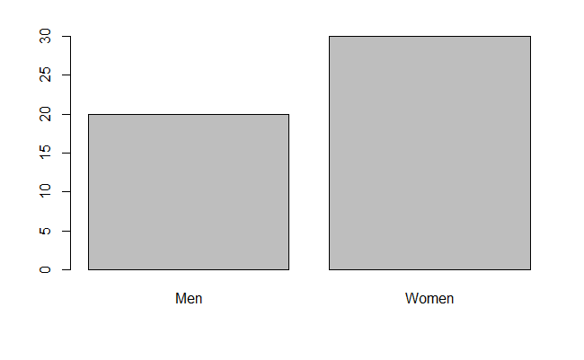

```r
barplot(table(data$Gender))
```

We can beautify the plot with better labelling and colors if we need to.

#### Boxplot

We can additionally use boxplots when dealing with categorical data and a continuous outcome. Boxplots help us to understand the distribution of our data and the extent to which there may be values that do not conform to the rest of the data. Again, we will use a basic boxplot here but there are options to beautify.

This boxplot will provide information about the distribution of scores based on the total number of questions in the test by gender.

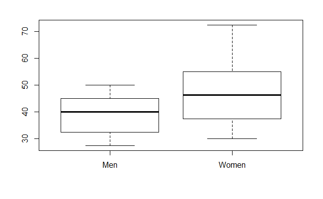

```r
boxplot(data$PercentTotal ~ data$Gender)
```

We can see from it that the distributions aren’t the same and that the average score for the women may be higher than for the men. We will come back to this in a later lecture.

#### Histograms

Histograms allow us to visualize the distribution of a continuous variable. It can give information about potentially miscoded values, outliers, and the extent to which our observations conform to an expected distribution (usually the normal distribution.

Histograms rely on binwidth. The binwidth simply defines how many values are encompassed by a bar. Here we produce a histogram of the scores on the test with the default bins.

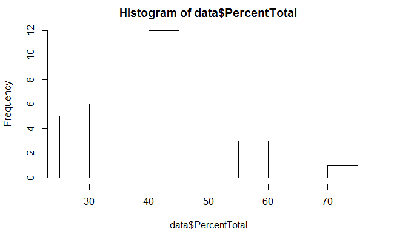

```r
hist(data$PercentTotal)
```

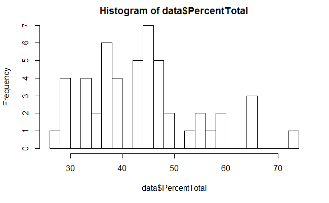

```r
hist(data$PercentTotal, breaks = 20)
```

By doubling the break points, we get more granularity and get to see more of the data. By contrast, if we halve the break points, we’ll see less.

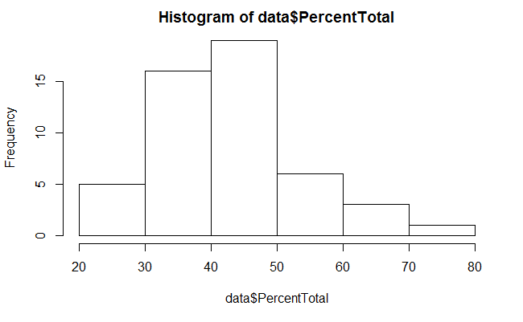

```r
hist(data$PercentTotal, breaks = 5)
```

Overall, these show us the general shape of our data. We can also get probabilities within bins by converting the y-axis to density (proportion in bin) and adding a density line over the top.

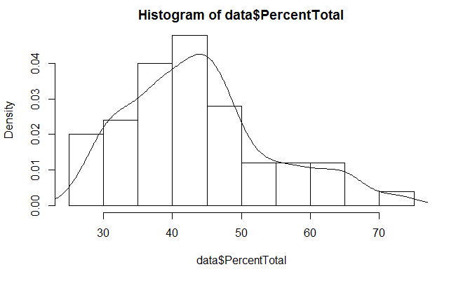

```r
hist(data$PercentTotal, freq = FALSE)
lines(density(data$PercentTotal))
```

And of course we can make use of graphical options to change the axis labels, colors, etc.

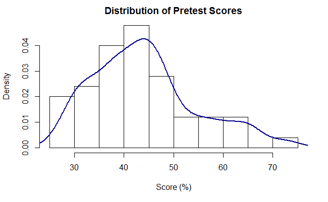

```r
hist(data$PercentTotal, freq = FALSE,
     main = "Distribution of Pretest Scores",
     xlab = "Score (%)")
lines(density(data$PercentTotal), col = "darkblue", lwd = 2)
```

#### Scatterplots

Scatterplots show us relationships between two continuous variables. They take an x- and y-axis argument. They are easy to create and customize. Here’s the basic scatterplot between the minutes taken on the test and score.

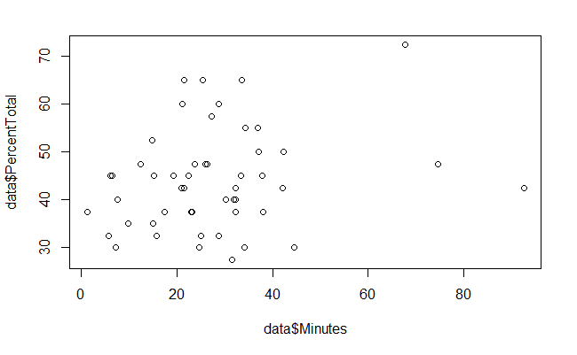

```r
plot(data$Minutes, data$PercentTotal)
```

Again, we can beautify a bit.

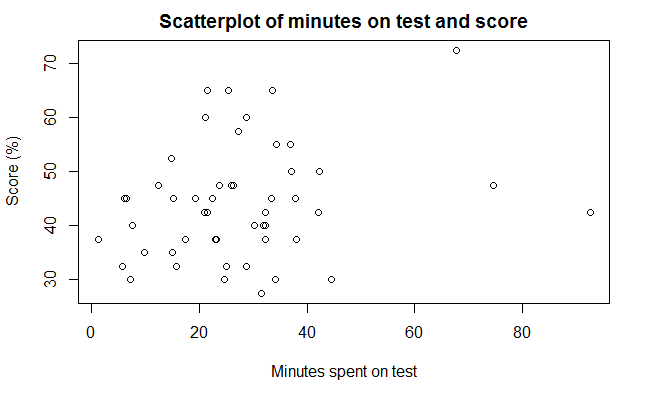

```r
plot(x = data$Minutes, y = data$PercentTotal,
     xlab = "Minutes spent on test",
     ylab = "Score (%)",
     main = "Scatterplot of minutes on test and score")
```

We can take this a step further and look for differences in patterns by gender. We can alter the shape, color, and/or size of the point based on gender.

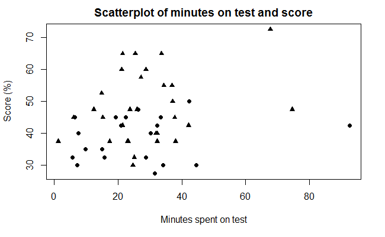

```r
plot(x = data$Minutes, y = data$PercentTotal,
     xlab = "Minutes spent on test",
     ylab = "Score (%)",
     main = "Scatterplot of minutes on test and score",
     pch = c(16, 17)[as.numeric(data$Gender)])
```

There are lots of graphical parameters and options when using base R. As we go through the course, we will also introduce ggplot which adds a lot of customization options and (in my opinion) produces much nicer plots overall.